# Modeling HIV Using SIR Models

S. Mang, L. Andrews, E. Holmes

May 22, 2017

In this study, we simulated the transmission of Human Immunodeficiency Virus (HIV) in a population using several SIR models. HIV is an infection caused by a retrovirus passed through fluid interactions, such as during seuxal intercourse or blood transfusions. In our SIR models, we manipulated different demographics and their respective interactions as the variables, exploring different age groups and heterosexual interactions. We used statistics gathered from the Center for Disease Control as some of our parameters.

In our specific model, we have three states an individual can identify as: susceptible, infected, and removed with p being the probability a person with HIV will have unprotected vaginal or anal intercourse with a susceptible person, alpha being the probability an infected person will pass HIV to a susceptible person through unprotected vaginal or anal intercourse, and beta being the probability an infected person with HIV will have their infection progress into AIDS, under the assumption that individuals with AIDS will no longer be sexually interactive with the susceptible population and are thereby removed. We analyzed the transmission patterns of HIV based on age group and gender separately before combining the two and exploring different situations.

### Stage 1: Isolated Age Groups

In this scenario, we created three different age groups using three distinct SIR models, so that sexual interactions only occur between members of the same age group. g1 consists of a group of young people (15-29) who have the highest probability of interaction (p) and transmission rate (alpha) since they are young and sexually active, which may make them less likely to use protection during sexual intercourse. g2 consists of middle aged people (30-49), and g3 is a group of older people (50-69) with the lowest probability of interaction and transmission rate since most people become less sexually active as they age. In this model, we assumed that there are sexual interactions only between the same age group.

To initiate our model, we first set the probability of interaction, alpha, and beta parameters for each respective age group.

In this function, we calcuate the number of individuals in the susceptible population that will stay susceptible after one time step. We find this by multiplying the probability a susceptible person will stay infected (1-alpha) against itself for the number of times a susceptible person has unprotected sexual interactions with an HIV positive indivual. The number of interactions is calculated using a binomial distribution based on the probability of interaction. Then, the state (susceptible or infected) of each individual is determined probabilistically and counted cummatively, so that the function outputs the number of individuals in the susceptible population that stay susceptible.

In a population of 100 susceptible people and ten HIV positive individuals, the following outputs are the number of indiviuals in the susceptible population who stayed susceptible after one time step in age group 1, 2, and 3 respectively.

```
## [1] 46
```

```
## [1] 75
```

```
## [1] 89
```

We see that the youngest age group has the smallest population of susceptibles who stay susceptible while the oldest age group has the most. This makes sense because the probability of the younger population engaging in unprotected sex and transmitting HIV is the highest amongst all three groups while the older population has the lowest p and alpha value and therefore have the largest number of the population staying susceptible.

To simulate an SIR model looking at one age group, we created a function that organizes the three populations (susceptible, infected, and removed) into one row of a three columned of a matrix. Then, based on the total population size (N), number of time steps (M), alpha value (alpha), and probability of interaction value (p), the matrix gets filled with each row representing a timestep of the total population and the number of individuals in each S, I, and R population.

Looking at the SIR model for each age group, we can see that the different probabilities of interaction and transmission affect the intensity of the propogation of HIV in the total population. The first column represents the susceptible population for age group 1, 2, and 3 respectively while the second column represents the infected population and the third column represents the removed population.

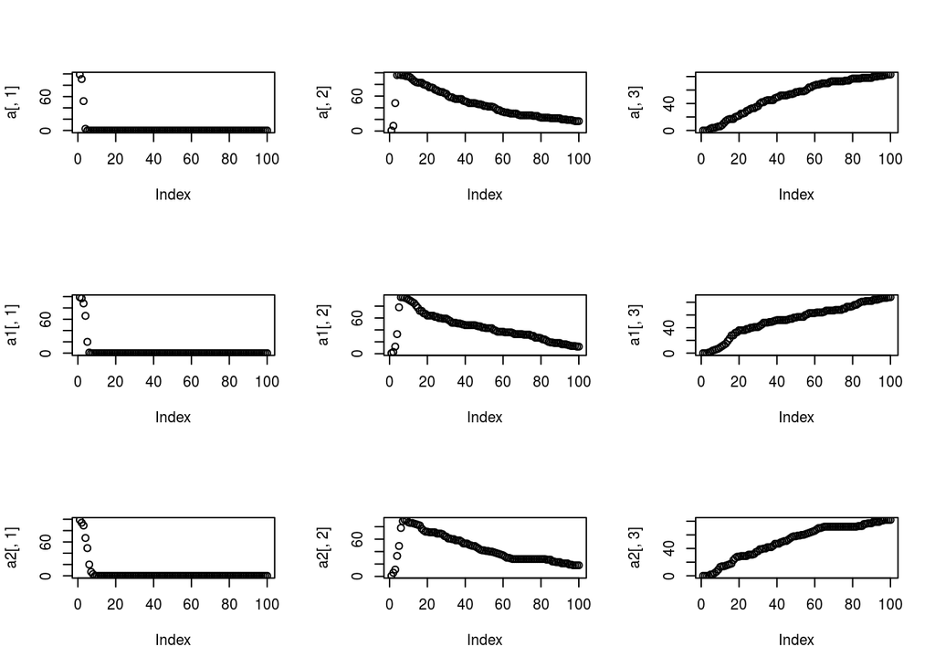

#### Comparing the Peak Values

Looking at the infected column in our SIR function’s matrix, we can identify the time step when there were the most infected individuals in the population.

```
## [1] 5
```

```
## [1] 6
```

```
## [1] 8
```

Given its larger probability of interaction rate, we can tell that g1 (young group) gets to the peak point faster than other two groups.

#### Plotting SIR model for Age Group

We used ggplot to visualize each the transmission of HIV in each population better!

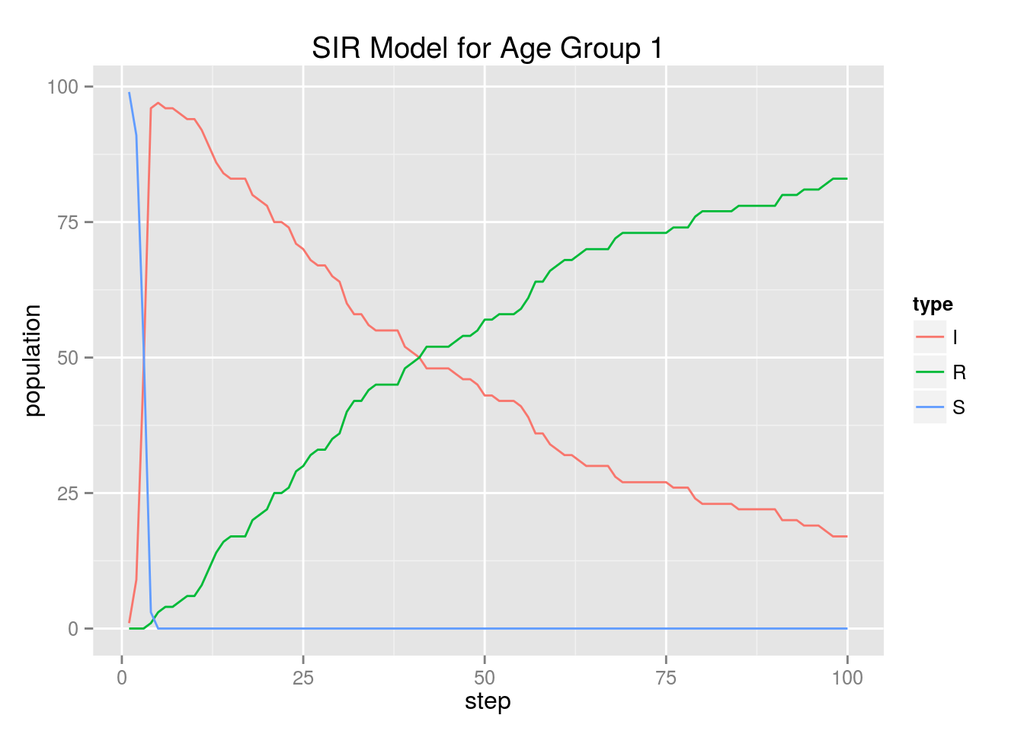

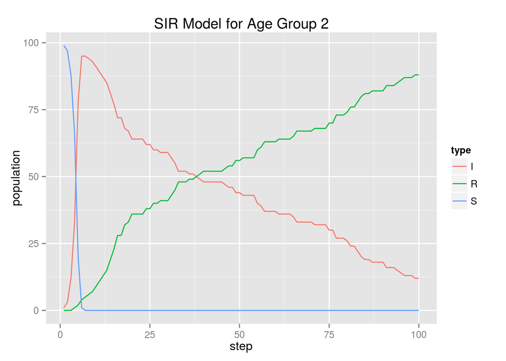

[figure not shown]

By drawing the graphs, we can see the trend that the susceptible population for all age groups dramatically decreases within the first ten time steps since our p and alpha are very large in this scenario. The infected population for all age groups dramatically increases at the beginning and gradually decreases as the time steps increase. The removed population gradually increases as the infected population decreases for all age groups, though the relative rates of the two varies between age groups.

### Stage 2: Interactive Age Groups

In this scenario, we assume that individuals of different age groups can interact with each other. To represent this, we created a symmetrical matrix of the probabilities of interaction with the infected age groups being the columns and the susceptible age groups consisting of the rows. We did not believe the probability of an unprotected sexual interaction between an HIV positive older person and a susceptible younger person (g1 row, g3 column) would vary significantly to that of an HIV positive younger person and a susceptible older person (g3 row, g1 column), which is why the matrix is symmetrical. We still have the assumption that young people engage in the most unprotected sexual encounters among three groups. Unlike the previous scenario, we are assuming that infected indivuals from all age groups have the same probability of transmitting HIV to a susceptible individual of any age group

```
##     g1  g2   g3
## g1 0.3 0.1 0.20
## g2 0.1 0.2 0.10
## g3 0.2 0.1 0.05
```

Since the probability of interaction is different depending on which groups are interacting, we made a function that returns the number of interactions the susceptible population of a specified age group (group 1) has with the specified infected population of a specified age group (group 2). Note that the variable names group 1 and group 2 do not refer to g1 or g2 necessarily. For example, to find the number of unprotected sexual interactions between the susceptible middle aged group and infected older group, the variable “group 1” would be 2 and the variable “group 2” would be 3.

For example, this vector illlustrates the number of young infected individuals 100 young susceptible individuals interacted with.

```
##   [1] 7 3 4 4 4 3 2 1 5 2 2 5 4 3 1 4 2 3 1 2 1 3 2 1 1 3 2 3 4 4 3 2 4 5 0
##  [36] 1 3 1 5 6 2 0 2 3 6 1 3 2 3 4 0 3 2 0 3 3 4 4 5 2 3 3 6 0 5 5 2 4 5 4
##  [71] 1 4 4 2 2 3 1 4 4 5 4 4 5 3 3 1 1 6 4 1 3 3 3 3 3 4 3 2 1 3
```

In this example, this vector illlustrates the number of middle aged infected individuals 100 young susceptible individuals interacted with.

```
##   [1] 1 0 1 1 1 0 1 1 0 2 1 1 1 1 0 3 1 1 0 1 2 1 1 1 1 2 2 1 1 1 0 0 1 1 1
##  [36] 1 2 1 3 2 3 1 0 0 0 0 1 1 1 1 0 2 1 1 0 1 0 1 0 0 1 2 0 0 2 0 0 0 1 1
##  [71] 1 0 1 1 2 1 2 1 1 2 1 1 1 0 1 3 0 1 0 1 0 1 1 1 2 1 1 1 1 2
```

Using our numofint function, we altered our original susNum function so that the probability a susceptible person will stay infected (1-alpha) will be multiplied against itself for the number of total interactions a susceptible individual has with the young age group, middle age group, and older age group. This function takes in Slast1, the number of susceptible people in the population; Ilast1, the number of infected people from g1; Ilast2, the number of infected people from g2; Ilast3, the number of infected people from g3; and group 1, which represents the age group (1, 2 or 3) of the susceptible population. Just like the original susNum function, the function determines the fate of each individual (susceptible or infected) probabilistically and then outputs the total number of individuals in the susceptible population that stay susceptible.

To test our function, in this example, there are 100 susceptible individuals from the young age group, 10 infected individuals from the young age group, 20 infected individuals from the middle age group, and 30 individuals from the oldest age group. The function outputs the number of individuals in the susceptible population that stay susceptible.

```
## [1] 31
```

We adapted our original SIR function that gives all the values of the S, I, and R populations to incorporate the interactions between different age groups. nage1, nage2, and nage3 set the initial populations of age group 1, age group 2, and age group 3 while M determines the number of time steps. In this specific model, there is one infected individual from each age group at time step 1, n-1 individuals in each of their respective susceptible populations, and no individuals in the removed populations for any age group.

In a model with initial populations of 100 for g1, g2, and g3 for 100 time steps, we can compare and constrast the SIR populations for each age group with the first column representing the S, I, and R populations of age group 1, the second column representing the S, I, and R populations of age group 2, and the third column representing the S, I, and R populations of age group 3, all by row.

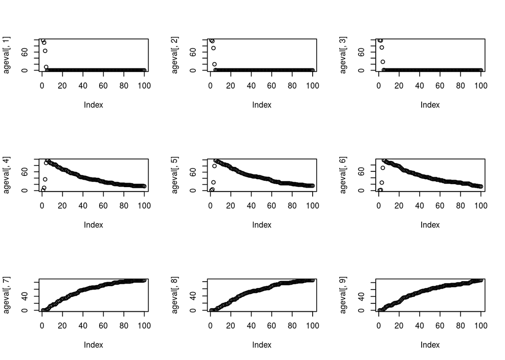

#### Comparing Peak Values

Looking at the infected column in our SIR function’s matrix, we can identify the time step when there were the most infected individuals in the population.

```
## [1] 5
```

```
## [1] 6
```

```
## [1] 5
```

#### Plotting SIR model for Age Group

We used ggplot to visualize and compare the transmission of HIV in each age group better.

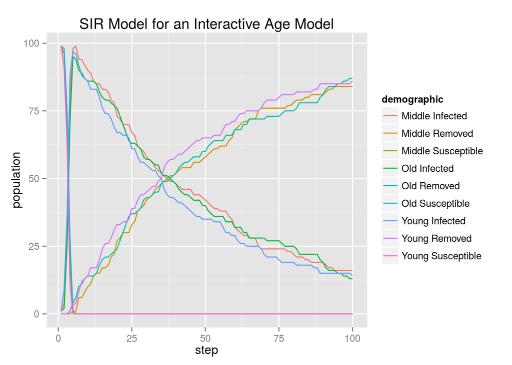

While the susceptible populations for all age groups seems to decrease at similar rates, the removed population for young individuals sees to increase faster than the removed population for middle and older individuals.

### Stage 3: Gender and Heterosexuality

Next, we wanted to model how HIV spreads through a population of heterosexual individuals, taking into account different probabilities of interaction and transmission between males and females. We decided to omit modeling homosexual individuals (even though they are significant amount of the current infected population) because the model is not quite as interesting. It would simply be a model with 2 independent susceptible, infected, and removed groups that wouldn’t interact with the other gender. What is interesting about the hetersexual model is that susceptible males interact with portions of infected females, and susceptible females interact wtih portions of infected males. Thus, the two genders rely on each other to spread throughout the population.

Below, we set up some parameters to run our model. We started with a population of 100 individuals (half male, half female), and established that the probability of interaction that an infected male will engage in unprotected sexual intercourse with a susceptible female is 0.3 and that the probability of unprotected sexual interaction between an infected female and susceptible male is 0.1. The probabilities of infection for males and females are 0.04 and 0.08 respectively according to the CDC. There is only one beta value because the probability of HIV progressing into AIDS varies little between genders.

We adapted our original susNum function, so that susNum2 takes in the number of susceptible individuals, the number of individuals in the opposite gender infected population, the alpha value for the susceptible group, and the interaction probability that matches the susceptible group. This function returns the number of originally susceptible people who remain susceptible after one time step.

To check our function, we compared the number of resulting susceptible individuals with a population with 100 susceptible females and five infected males and a population with 100 suceptible males and five infected females.

```
## [1] 89
```

```
## [1] 99
```

Alright, we are ready to run the actual model. We start with all individuals susceptible except for one male and one female. We will run the model with 50 males and 50 females over 100 time steps.

The table below shows results for susceptible, infected, and removed over time steps. The graphs in the first column corresponds to the male data, and the second column graphs correspond to the female population.

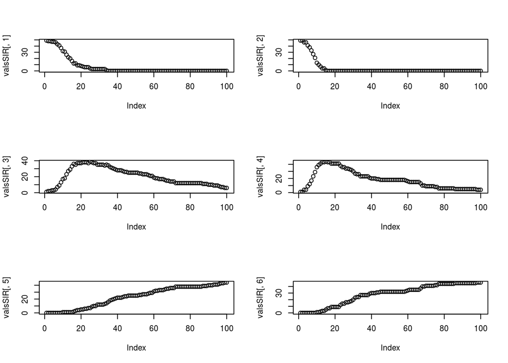

As we see in the charts for susceptible groups, the female group dropped off the quickest. This was likely due to our interaction probability values, since the value for infected male to susceptible female was three times the size of the infected female to susceptible female. However, the whole population had very similar trends across gender, likely because each group draws on the other to calculate each time-step.

Next, we adapted our original SIR function to encapsulate everything so far.

To check our function, we examined a population with fifty males and fifty females over 100 time steps.

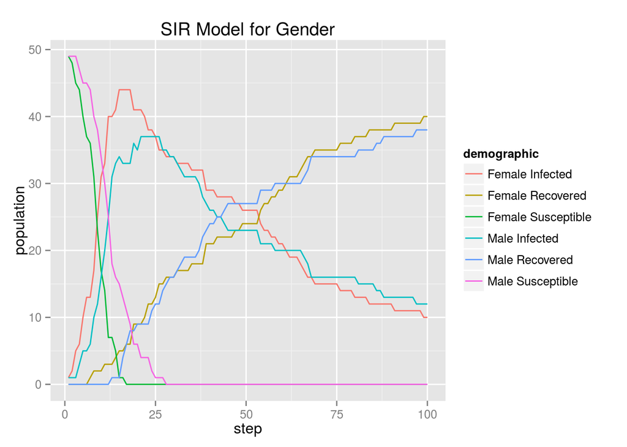

In our model, we see that there is a significant disparity between male and female HIV trends. We see that males stay susceptible longer than females and reach their maximum number of infected individuals later than females. Similarly, the infected male population progress to AIDS later than females. Desipte the slight delay in time steps, much of the trends between female and male populations parallel each other.

### Stage 4: Accounting for Age and Gender Before Treatment

In this stage, we combined the interactive models we have created so far. We created two assymetrical probability matrices for establishing the probabilities of interaction between age groups and genders because we believe there is a significant difference in the probabilities of unprotected sexual interaction between infected males of various age groups and susceptible females of various age groups and infected females of various age groups and susceptible males of various age groups. The prob_mf_matrix represents the probabilities of interaction between infected males and susceptible females while the prob_fm_matrix represents the probabilities of interactions between infected females and susceptible males. Like our earlier age probability matrix, the infected age groups of a certain gender are represented by the columns and the susceptible age groups of the opposite gender are represented by the rows. For example, the probability of interaction between an infected young male and a susceptible middle aged female corresponds to the second row and first column of the prob_mf_age matrix.

```
##                     infected male1 infected male2 infected male3
## susceptible female1          0.030          0.030          0.015
## susceptible female2          0.025          0.020          0.008
## susceptible female3          0.015          0.005          0.005
```

```
##                   infected female1 infected female2 infected female3
## susceptible male1            0.025            0.015            0.010
## susceptible male2            0.020            0.020            0.015
## susceptible male3            0.010            0.007            0.005
```

We continued to use the same alpha values from the CDC website that only relate to gender, not specific age groups. In this model, we chose a beta value to represent how HIV might progress to AIDS without the more effective treatments available today (discovered in the late 90’s/early 2000’s). Later we update the model to account for advances in medicine and analyze and compare how that affects the model.

We also updated our functions from before, to account for the more complicated interactions going on. Our new interaction function outputs a vector that represents the number of interactions each susceptible individual has with infected individuals from one age group of the opposite sex.

To check our function, we looked at the number of interactions a population of 100 susceptible young girls have with 10 older infected men.

```
##   [1] 0 0 0 0 0 0 1 0 0 0 0 0 0 0 0 0 1 0 0 0 0 0 0 0 0 0 0 1 1 0 1 0 0 0 1
##  [36] 0 0 0 1 0 0 0 0 1 0 0 0 0 0 0 1 0 1 0 0 0 0 0 0 0 1 0 0 1 0 0 0 0 0 0
##  [71] 0 2 0 0 0 0 0 0 0 0 0 1 0 0 0 0 0 0 2 1 0 0 0 0 0 1 1 0 0 0
```

Using our adapted interaction function, we calculated the total interactions a susceptible individual has with each age group of the opposite sex.

To check our function, we looked at the total number of interactions a population of 100 susceptible young girls have with ten infected men from each age group.

```
##   [1] 0 1 0 2 0 1 1 1 0 0 0 0 0 0 3 2 1 1 0 1 0 1 1 2 0 0 2 0 1 2 0 0 1 1 0
##  [36] 3 1 0 0 1 1 1 0 0 1 0 0 0 1 2 0 1 1 0 0 1 3 1 0 0 2 0 1 0 2 1 0 0 3 1
##  [71] 1 1 0 2 0 2 1 0 0 0 0 0 0 0 1 1 2 1 1 0 2 0 3 0 1 0 4 0 1 1
```

We adapted our original susNum function, so that susNum3 takes in the number of susceptible individuals, the number of individuals in the infected population of the opposite gender for every age group, the alpha value for the susceptible group, and the interaction probability matrix that matches the interaction. This function returns the number of originally susceptible people who remain susceptible after one time step.

To test this function, we see the number of young susceptible females who remain susceptible while probabilistically interacting with ten infected males from each age group.

```
## [1] 93
```

With the parameters and functions adjusted, it is time to run the new model! Our population consists of 1800 individuals, with 300 individuals in each gender’s age group over 100 time steps.

Using ggplot, we can visualize and analyze the trends of different demographics in the population.

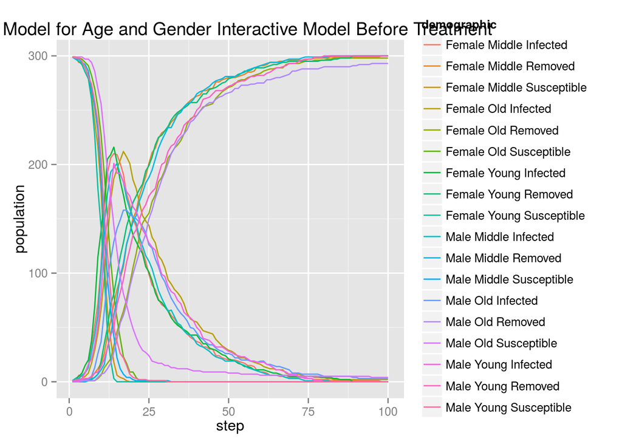

While this model does not clearly define what the time step is (months, years, decades), another issue in the model is how the probability of interaction scales. As the infected group grows larger, each susceptible person interacts with more and more infected people. While this aspect may pertain to diseases spread by physical contact, it may not accurately reflect the sexual activities of real people because while the population of HIV positive people increases the probability of engaging in sexual activity with them also increases, there is an upper limit of the amount of sex people generally have. This is something to keep in mind with this model.

### Stage 5: Accounting for Age and Gender with Treatment

While the previous model incorporated a beta reflective of the number people who died from AIDS before effective treatments were available, this model uses a lower beta to see how that affects the SIR model.

We ran this model with the same initial conditions, with a population of 1800 individuals, with 300 individuals in each gender’s age group over 100 time steps.

Using ggplot, we can visualize and analyze the trends of different demographics in the population.

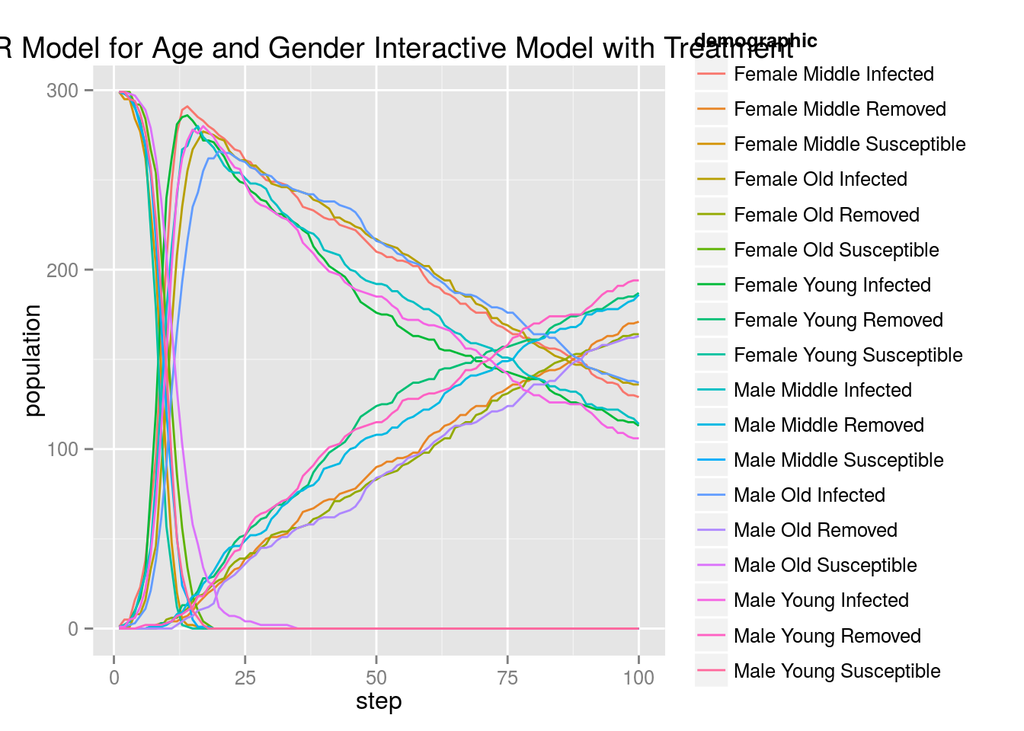

With the decreased beta value, within 100 time steps, a little more than half of the population is removed, rather than nearly the entire population in the previous model. With more people staying in the infected population longer, the susceptible population eliminates faster than in the previous model, with young and middle aged females infected the fastest. Similarly, looking at the maximum number of infected poplations for each demographic, the populations are closer in size than when the beta value in the previous model was higher.

### Stage 6: Restricted Young Female and Male Interaction

Since young females seem to be the most susceptible to being infected by HIV, we thought it would be interesting to eliminate their interactions with males of all age groups to see how that would affect our model. To carry this out, we changed our probability of interaction matrix, but kept the alpha and beta values the same as our previous model.

```
##                     infected male1 infected male2 infected male3
## susceptible female1          0.000          0.000          0.000
## susceptible female2          0.025          0.020          0.008
## susceptible female3          0.015          0.005          0.005
```

```
##                   infected female1 infected female2 infected female3
## susceptible male1                0            0.015            0.010
## susceptible male2                0            0.020            0.015
## susceptible male3                0            0.007            0.005
```

We used the same initial conditions as the previous stages for easy comparison purposes, with 300 individuals in each demographic with 1800 individuals total for 100 time steps.

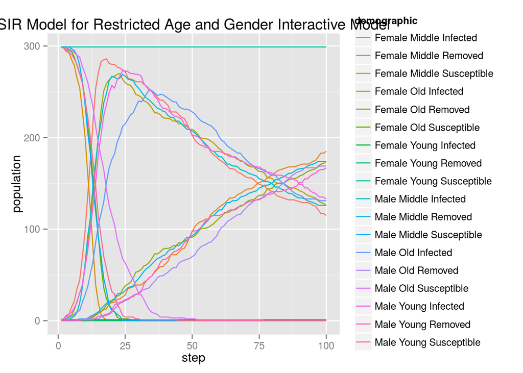

### Stage 7: Using U.S. Age and Gender Demographics

In this model, we used data from the 2010 U.S. census for our initial conditions. The probabilities of interaction, alphas, and betas were reverted back to those of stage 5 with all age groups for both genders interacting with each other.

Instead of using arbitrary intitial conditions, we set our age and gender group populations to reflect U.S. age and gender groups in 2010 on a smaller scale. We defined our young age group as individuals ages 15-29, our middle aged group as 30-49 yearas old, and our older age group as 50-70 years of age. We carried this model out with 100 time steps.

We used the same function as stage 5 and started our model with one infected person in each demographic.

We used ggplot to visualize and analyze the trends of different demographics in the population.

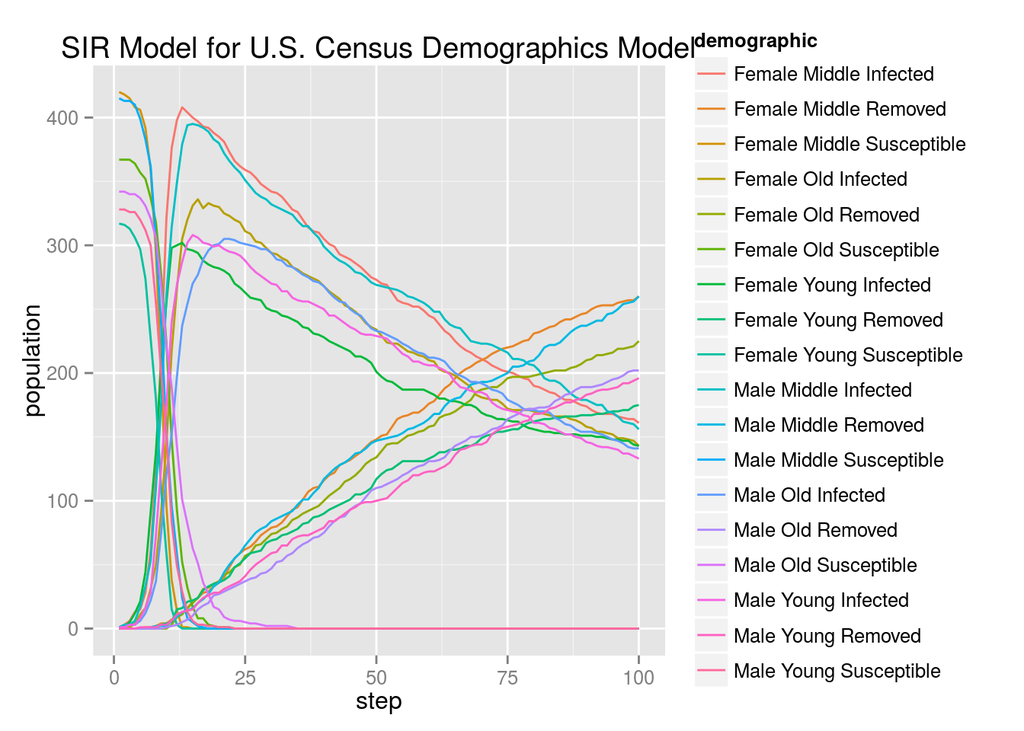

While in previous models, younger females were the earliest group to hit their maximum infected population and had the highest maximum value, in the U.S. census model, young females still reach their maximum infected population earliest, but middle aged men and women, who are the largest population, have the highest infected populations. Since the initial populations vary, the relative positions of the S, I, and R models vary, but the trajectories remain relatively parallel and consistent with previous models.

### Conclusion

In this study, we explored several different HIV SIR models, looking at how the disease progresses based on the interactions between different age groups and genders. While our SIR model is very informative about the nature of a disease, we could increase our accuracy by explictly determining the size of time steps, which would help solidify parameters p, alpha, and beta. Additionally, we could explore other factors that play into the transmission of HIV such as race and sexuality, different routes of HIV transmission, birth rates and death rates, and HIV treatments. Nevertheless, our model is a sufficient starting point to explore this disease further.